# Pull the Lever, Kronk!

### Introduction

One of my close friends who I also consider to be an extremely bright individual surprised me during lunch one day. He was a portfolio manager working within a big bank and yet when it came to his personal finances, he had told me that all of his capital was invested in geared equity index products. To me this notion sounded absurd - leveraged ETFs, just as cryptocurrencies and the latest hot stock tips were the realm of investment junkies looking for a quick lottery win. Certainly not the school of thought to be pursued by the business scool educated elite who were taught 'sound' investment practices and to be selectively sceptical of too-good-to-be-true investment proposals. Returning to my peculiar friend's confession, I badgered the point a bit further. Surely a simple performance chart would articulate my feelings - leverage is a double-edged sword and so the good times will come to nought once you overshoot the optimal Kelly during a bear market and are unable to recoup your losses.

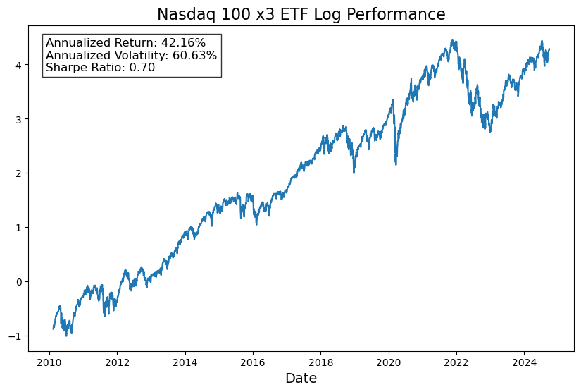

```python
import yfinance as yf
from datetime import datetime, timedelta
import seaborn as sns
import numpy as np
import warnings
import matplotlib.pyplot as plt
import pandas as pd
import random

warnings.simplefilter(action='ignore', category=FutureWarning)

priceData = yf.download('TQQQ', start='2000-01-01', end=datetime.today(), progress=False)['Adj Close']
dailyReturns = priceData.pct_change()
annReturn = (((priceData[-1] / priceData[0]) ** (365 / (priceData.index[-1] - priceData.index[0]).days)) - 1) * 100
annVolatility = dailyReturns.std() * np.sqrt(252) * 100
sharpeRatio = (annReturn / annVolatility)

plt.figure(figsize=(10, 6))
plt.plot(np.log(priceData))
plt.title('Nasdaq 100 x3 ETF Log Performance', fontsize=16)
plt.xlabel('Date', fontsize=14)
text_box = f'Annualized Return: {annReturn:.2f}%\nAnnualized Volatility: {annVolatility:.2f}%\nSharpe Ratio: {sharpeRatio:.2f}'
plt.text(0.15, 0.85, text_box, transform=plt.gcf().transFigure,
         verticalalignment='top', horizontalalignment='left', fontsize=12, bbox=dict(facecolor='white', alpha=0.8))
plt.show()
```

### Impact of Time-Dependency

It would be fair to challenge plotting the best performing index during a bull market. As an alternative exercise, I have plotted a histogram of annualised returns for 10,000 random entry/exit points into a x2 leveraged S&P 500 strategy using over one hundred years of price history. Doing so results in approximately 90% of positive annualised returns with a healthy average of 13%. The minimum holding period has been set to 3 years, however increasing this results in a higher proportion of positive returns.

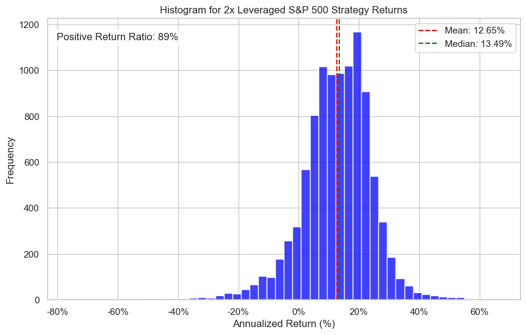

```python
import yfinance as yf
import numpy as np
import seaborn as sns
import matplotlib.pyplot as plt
import random

# Function to calculate annualized returns
def calculate_annualized_return(start_value, end_value, periods):
    return (end_value / start_value) ** (1 / periods) - 1

# Function to perform a backtest for a random time window
def backtest_random_window(data, leverage=2, min_days=252*3, max_days=252*20):
    start_idx = random.randint(0, len(data) - max_days)
    end_idx = random.randint(start_idx + min_days, min(start_idx + max_days, len(data) - 1))
    start_price = data['Adj Close'].iloc[start_idx]
    end_price = data['Adj Close'].iloc[end_idx]
    days_held = (data.index[end_idx] - data.index[start_idx]).days / 365.25
    raw_return = calculate_annualized_return(start_price, end_price, days_held)
    leveraged_return = leverage * raw_return
    return leveraged_return, days_held

# Download S&P 500 data
data = yf.download("^GSPC", '1900-01-01', '2025-01-01', progress=False)

# Run simulations
num_simulations = 10000
returns = []
for _ in range(num_simulations):
    result, days_held = backtest_random_window(data)
    returns.append(result)
returns = np.array(returns)

# Compute simulation stats
mean_return = np.mean(returns)
median_return = np.median(returns)
positive_ratio = np.sum(returns > 0) / len(returns)

# Plot histogram of returns
sns.set(style="whitegrid")
plt.figure(figsize=(10, 6))
sns.histplot(returns, bins=50, kde=False, color='blue')
plt.axvline(mean_return, color='red', linestyle='--', label=f'Mean: {mean_return:.2%}')
plt.axvline(median_return, color='green', linestyle='--', label=f'Median: {median_return:.2%}')
text_box = f'Positive Return Ratio: {positive_ratio:.0%}'
plt.text(0.02, 0.95, text_box, transform=plt.gca().transAxes,
         verticalalignment='top', horizontalalignment='left', fontsize=12,
         bbox=dict(facecolor='white', alpha=0.8))
plt.gca().xaxis.set_major_formatter(plt.FuncFormatter(lambda x, _: f'{x:.0%}'))
plt.xlabel("Annualized Return (%)")
plt.ylabel("Frequency")
plt.title("Histogram for 2x Leveraged S&P 500 Strategy Returns")
plt.legend()
plt.show()
```

### On Common Sense

Historical blow-ups would suggest avoiding excessive leverage and there is probably a lot of sense in that. Nonetheless, I would like to summarise a couple arguments entertaining the notion of leveraged beta:

- There is no guarantee that any asset should continue to rise in the future, however with broad equity exposures this has at least been true historically. Economies continue to grow, new technologies are developed and our entire pension system relies on it. Major market-cap indices are efficiently designed to maintain exposure to winners and to cut out the losers - so even if we do see a sector rotation, this would be traced within the benchmark. The exposure is in itself a reflection of capitalism and the rise of passive investing only amplifies its lopsided gains.
- My second argument is more pragmatic - maximising exposure to beta generally increases absolute returns. Perhaps not risk-adjusted, but as the old adage goes, you can't eat Sharpe Ratio. The distribution of returns discussed previously is hard to dispute with and if there is hesitation around potentially being caught in the unlucky proportion of losing periods, dollar cost averaging with a healthy dose of patience should be remedial.